# Comparing Airports

**Is the number of delayed flights at Newark significantly greater than at other New York airports?**

## Average Delays

```r
departures %>%
  summarise(mean(dep_delay), sd(dep_delay))
```

| mean(dep_delay) | sd(dep_delay) |
| --- | --- |
| 15.18722 | 52.04006 |

```r
departures %>%
  filter(dep_delay <= (mean(dep_delay) + 5*sd(dep_delay))) %>% # removing extreme outliers
  group_by(origin) %>%
  summarise(mean_delay = mean(dep_delay), median_delay = median(dep_delay))
```

| origin | mean_delay | median_delay |
| --- | --- | --- |
| EWR | 13.68109 | -2 |
| JFK | 12.49371 | -2 |
| LGA | 11.86344 | -2 |

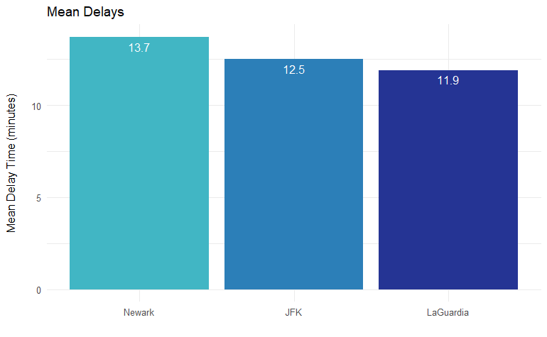

```r
departures %>%
  filter(dep_delay <= (mean(dep_delay) + 5*sd(dep_delay))) %>% # removing extreme outliers
  group_by(origin) %>%
  summarise(mean_delay = round(mean(dep_delay), 1)) %>%
  ggplot(aes(x = origin, y = mean_delay, fill = origin)) +
  geom_col() +
  geom_text(aes(label = mean_delay),
            vjust = 1.5,
            colour = "white") +
  labs(x = "",
       y = "Mean Delay Time (minutes)\n",
       title = "Mean Delays",
       fill = "") +
  scale_fill_manual(values = x3colours) +
  scale_x_discrete(labels = c("Newark", "JFK", "LaGuardia")) +
  guides(fill = "none") +

  theme_minimal()
```

After the most extreme delays have been removed, Newark is found to have a mean delay time that exceeds JFK by 1.2 minutes and LaGuardia by 1.8 minutes. All airports have the same median: over half of flights leave the gate at least two minutes before their scheduled departure time.

## Proportion of delayed flights

```r
departures %>%
  group_by(origin) %>%
  summarise(prop_delayed = sum(delayed_flag)/n())
```

| origin | prop_delayed |
| --- | --- |
| EWR | 0.2467563 |
| JFK | 0.2272034 |
| LGA | 0.2169045 |

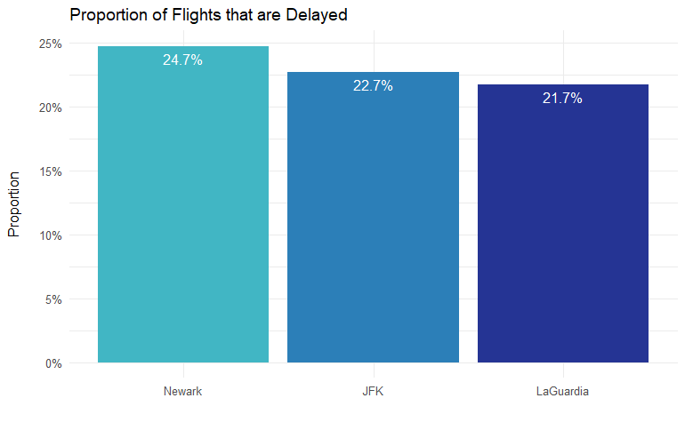

```r
departures %>%
  group_by(origin) %>%
  summarise(prop_delayed = round(sum(delayed_flag)/n(), 3)) %>%
  ggplot(aes(x = origin, y = prop_delayed, fill = origin)) +
  geom_col() +
  geom_text(aes(label = str_c(100*prop_delayed, "%")),
            vjust = 1.5,
            colour = "white") +
  labs(x = "",
       y = "Proportion\n",
       title = "Proportion of Flights that are Delayed",
       fill = "") +
  scale_fill_manual(values = x3colours) +
  scale_x_discrete(labels = c("Newark", "JFK", "LaGuardia")) +
  scale_y_continuous(labels = scales::percent) +
  guides(fill = "none") +
  theme_minimal()
```

Almost a quarter (24.7%) of flights from Newark are delayed by at least 15 minutes, while 22.7% and 21.7% of flights from JFK and LaGuardia are similarly delayed.

## Box plot / five number summary

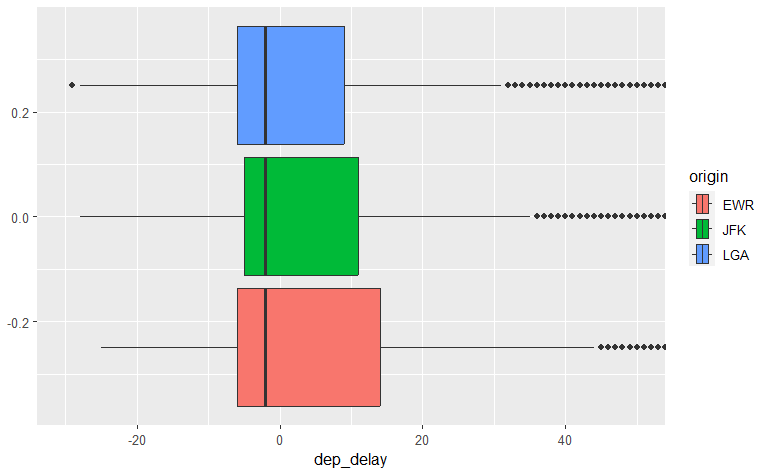

```r
departures %>%
  ggplot(aes(x = dep_delay, group = origin, fill = origin)) +
  geom_boxplot() +
  coord_cartesian(xlim = c(-30, 50))
```

```r
departures %>%
  group_by(origin) %>%
  reframe(five_num_summary = c("L", "Q1", "Q2", "Q3", "H"),
          delay = quantile(dep_delay, seq(0, 1, 0.25))) %>%
  pivot_wider(id_cols = origin, names_from = five_num_summary, values_from = delay)
```

| origin | L | Q1 | Q2 | Q3 | H |
| --- | --- | --- | --- | --- | --- |
| EWR | -25 | -6 | -2 | 14 | 1217 |
| JFK | -84 | -5 | -2 | 11 | 1301 |
| LGA | -29 | -6 | -2 | 9 | 1548 |

Of the three airports, Newark takes the longest time to dispatch 75% of flights.

## Hypothesis Test: Are there *significantly* more flight delays from Newark?

H<sub>0</sub>: You are **not** more likely to be delayed if you fly from EWR than other NYC airports.  
H<sub>1</sub>: You are more likely to be delayed if flying from EWR than other NYC airports.  
Level of significance chosen to be 5%.

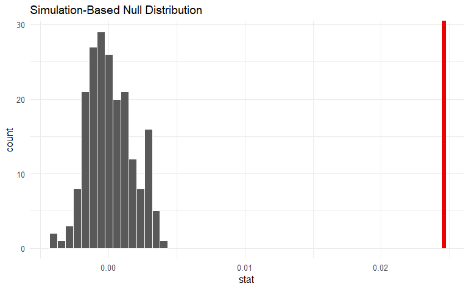

```r
origin_delayed <- departures %>%
  select(origin, delayed_flag) %>%
  mutate(origin = if_else(origin == "EWR", "EWR", "other"),
         delayed_flag = as.character(delayed_flag))

observed_stat <- origin_delayed %>%
  specify(delayed_flag ~ origin, success = "1") %>%
  calculate(stat = "diff in props", order = c("EWR", "other"))

null_distribution <- origin_delayed %>%
  specify(delayed_flag ~ origin, success = "1") %>%
  hypothesize(null = "independence") %>%
  generate(reps = 200, type = "permute") %>%
  calculate(stat = "diff in props", order = c("EWR", "other"))

null_distribution %>%
  visualise() +
  shade_p_value(obs_stat = observed_stat, direction = "right") +
  theme_minimal()
```

```r
p_value <- null_distribution %>%
  get_p_value(obs_stat = observed_stat, direction = "right")
p_value
```

| p_value |
| --- |
| 0 |

With a p-value approaching zero, we are forced to reject the null hypothesis. Hence, flights are more likely to be delayed if flying from EWR than other NYC airports.

## At what time of year and what time of day does Newark perform worse than other airports?

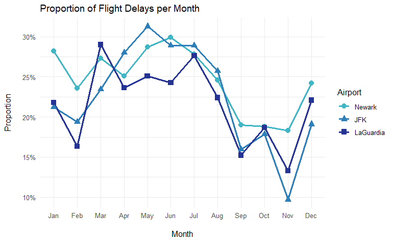

```r
departures %>%
  mutate(month = factor(month(time_hour, label = TRUE, abbr = TRUE))) %>%
  group_by(origin, month) %>%
  summarise(prop_delayed = sum(delayed_flag)/n()) %>%
  ggplot() +
  geom_line(aes(x = month, y = prop_delayed, group = origin, colour = origin), linewidth = 1) +
  geom_point(aes(x = month, y = prop_delayed, group = origin, colour = origin, shape = origin), size = 3) +
  labs(x = "\nMonth",
       y = "Proportion\n",
       title = "Proportion of Flight Delays per Month") +
  scale_y_continuous(labels = scales::percent) +
  scale_colour_manual(name = "Airport",
                      labels = c("Newark", "JFK", "LaGuardia"),
                      values = x3colours) +
  scale_shape_manual(name = "Airport",
                     labels = c("Newark", "JFK", "LaGuardia"),
                     values = c(16, 17, 15)) +
  theme_minimal()
```

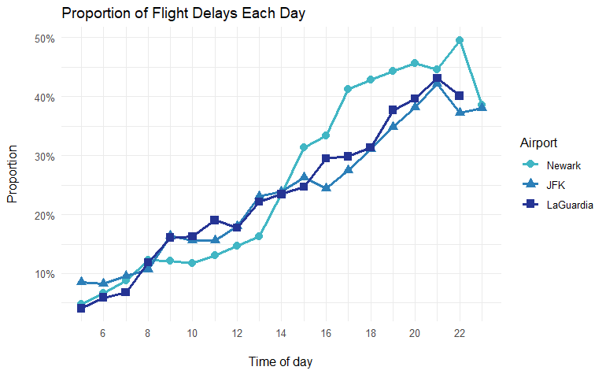

```r
departures %>%
  mutate(hour = hour(time_hour)) %>%
  group_by(origin, hour) %>%
  summarise(prop_delayed = sum(delayed_flag)/n()) %>%
  ggplot() +
  geom_line(aes(x = hour, y = prop_delayed, colour = origin), linewidth = 1) +
  geom_point(aes(x = hour, y = prop_delayed, colour = origin, shape = origin), size = 3) +
  labs(x = "\nTime of day",
       y = "Proportion\n",
       title = "Proportion of Flight Delays Each Day") +
  scale_x_continuous(breaks = seq(6, 24, 2), limits = c(5,23)) +
  scale_y_continuous(labels = scales::percent) +
  scale_colour_manual(name = "Airport",
                      labels = c("Newark", "JFK", "LaGuardia"),
                      values = x3colours) +
  scale_shape_manual(name = "Airport",
                     labels = c("Newark", "JFK", "LaGuardia"),
                     values = c(16, 17, 15)) +
  theme_minimal()
```

```r
departures %>%
  filter(dep_delay <= (mean(dep_delay) + 5*sd(dep_delay)), # removing outliers
         sched_dep_time >= 1500) %>% # only after 3pm
  group_by(origin) %>%
  summarise(after_3pm_mean_delay = mean(dep_delay),
            after_3pm_median_delay = median(dep_delay))
```

| origin | after_3pm_mean_delay | after_3pm_median_delay |
| --- | --- | --- |
| EWR | 26.67087 | 4 |
| JFK | 20.46674 | 0 |
| LGA | 20.97252 | 0 |

```r
departures %>%
  mutate(month = month(time_hour)) %>%
  filter(dep_delay <= (mean(dep_delay) + 5*sd(dep_delay)), # removing outliers
         month %in% c(11, 12, 1, 2)) %>% # only Nov - Feb
  group_by(origin) %>%
  summarise(winter_mean_delay = mean(dep_delay),
            winter_median_delay = median(dep_delay))
```

| origin | winter_mean_delay | winter_median_delay |
| --- | --- | --- |
| EWR | 11.931763 | -2 |
| JFK | 7.596038 | -3 |
| LGA | 8.504744 | -3 |

```r
departures %>%
  mutate(month = month(time_hour)) %>%
  filter(dep_delay <= (mean(dep_delay) + 5*sd(dep_delay)), # removing outliers
         month %in% c(11, 12, 1, 2), # only Nov - Feb
         sched_dep_time >= 1500) %>% # only after 3pm
  group_by(origin) %>%
  summarise(winter_after_3pm_mean_delay = mean(dep_delay),
            winter_after_3pm_median_delay = median(dep_delay))
```

| origin | winter_after_3pm_mean_delay | winter_after_3pm_median_delay |
| --- | --- | --- |
| EWR | 22.60107 | 2 |
| JFK | 11.96728 | -2 |
| LGA | 14.88260 | -1 |

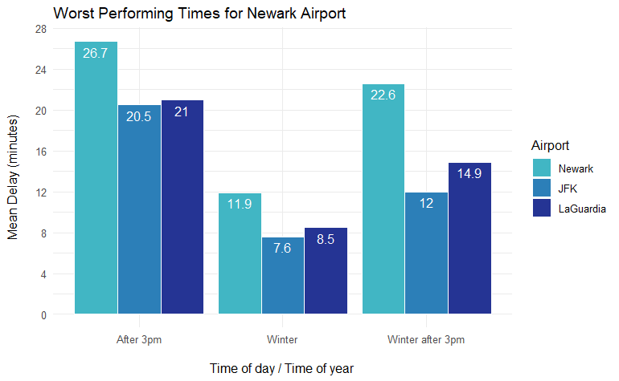

After 3pm, Newark is found to have a mean delay time that exceeds JFK by 6.2 minutes and LaGuardia by 5.7 minutes. In winter (Nov - Feb), Newark is found to have a mean delay time that exceeds JFK by 4.3 minutes and LaGuardia by 3.4 minutes. In winter *and* after 3pm, Newark is found to have a mean delay time that exceeds JFK by 10.6 minutes and LaGuardia by 7.7 minutes.

## Are particular flights from Newark delayed more regularly than others?

| dest | carrier | flight | number | prop_delayed | mean_delay |
| --- | --- | --- | --- | --- | --- |
| JAX | EV | 3973 | 12 | 1.0000000 | 72.91667 |
| CLT | UA | 1546 | 20 | 0.9500000 | 102.45000 |
| MDW | WN | 927 | 29 | 0.9310345 | 60.10345 |
| MDW | WN | 1196 | 31 | 0.9032258 | 73.61290 |
| PHX | WN | 1701 | 29 | 0.8620690 | 67.31034 |
| MCO | WN | 1113 | 29 | 0.7931034 | 70.20690 |
| JAX | EV | 4274 | 14 | 0.7857143 | 58.35714 |
| MDW | WN | 985 | 46 | 0.7826087 | 52.41304 |
| MDW | WN | 977 | 45 | 0.7777778 | 65.00000 |
| DTW | DL | 1327 | 36 | 0.7500000 | 43.44444 |

[output cut: 128 more lines]

There are 138 regular routes that suffer delays on most of their journeys that depart from Newark. These account for 9786 journeys in 2017 - almost a third of delays.

# Conclusions

Fundamentally, Newark performs more poorly than the other large New York airports when considering delays.

- On average delays are longer, especially in winter and after 3 pm
- Greater proportion of flights delayed
- Greater likelihood to be delayed at Newark, with a very high mathematical significance
- Certain routes contribute a disproportionate number of delays

Recommendations

- Allow more time on schedules, starting with routes that are most regularly delayed
- Increase ground staff in winter and after 3 pm
- Take steps to improve customer experience in the event of delay
  - food vouchers
  - improve facilities
  - entertainment